# Reproducible Research: Peer Assessment 1

Timothy A. Grove

September 15, 2015

## Load the required Packages and set working directory

#### 1. Packages required

```r
library(ggplot2)
library(Hmisc)
library(lattice)
```

#### 2. Set local working directory. This assumes the following:

- GitHub is located in default location on the local system
- The repository “RepData_PeerAssessment1” has been forked and replicated locally

```r
setwd("~/GitHub/RepData_PeerAssessment1")
```

## Loading and preprocessing the data

#### 1. Load the data (i.e. read.csv())

```r
activity <- read.csv('activity.csv')
```

## What is mean total number of steps taken per day?

NOTE: The missing values in the dataset can be ignored for these steps.

#### 1. Calculate the total number of steps taken per day

```r
stepsByDay <- tapply(activity$steps, activity$date, sum, na.rm=TRUE)
```

#### 2. Make a histogram of the total number of steps taken each day

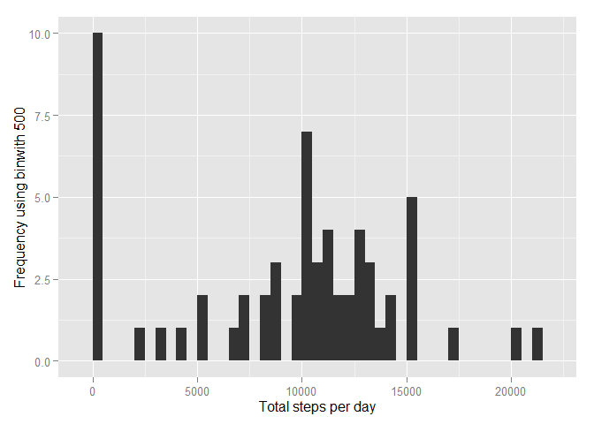

```r
qplot(stepsByDay, xlab='Total steps per day', ylab='Frequency using binwith 500', binwidth=500)
```

#### 3. Calculate and report the mean and median total number of steps taken per day

```r
stepsByDayMean <- mean(stepsByDay)
stepsByDayMedian <- median(stepsByDay)
```

Steps taken per day:

- Mean: 9354.2295082
- Median: 10395

## What is the average daily activity pattern?

In order to perform the follwing steps, create a data frame of the aggregated data

```r
averageDailySteps <- aggregate(x=list(meanSteps=activity$steps), by=list(interval=activity$interval), FUN=mean, na.rm=TRUE)
```

#### 1. Make a time series plot (i.e. type = “l”) of the 5-minute interval (x-axis) and the average number of steps taken, averaged across all days (y-axis)

- Panel using ggplot2

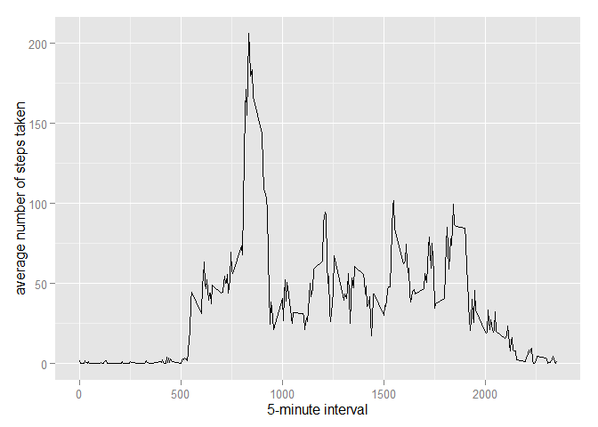

```r
ggplot(data=averageDailySteps, aes(x=interval, y=meanSteps)) +
    geom_line() +
    xlab("5-minute interval") +
    ylab("average number of steps taken")
```

- Panel using lattice

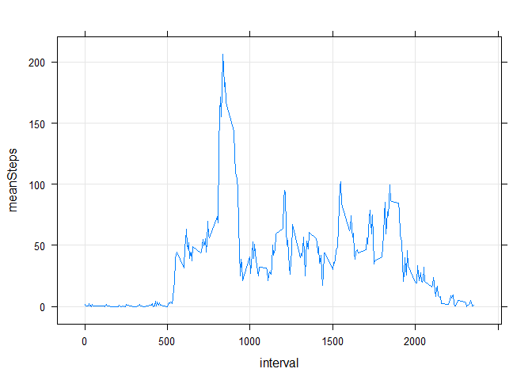

```r
xyplot(meanSteps ~ interval,
       data = averageDailySteps,
       type = c("l","g")
)
```

#### 2. Which 5-minute interval, on average across all the days in the dataset, contains the maximum number of steps?

```r
mostSteps <- which.max(averageDailySteps$meanSteps)
timeMostSteps <-  gsub("([0-9]{1,2})([0-9]{2})", "\\1:\\2", averageDailySteps[mostSteps,'interval'])
```

- Most Steps at: 8:35

## Imputing missing values

There are a number of days/intervals where there are missing values (coded as NA). The presence of missing days may introduce bias into some calculations or summaries of the data.

#### 1. Calculate and report the total number of missing values in the dataset (i.e. the total number of rows with NAs)

```r
numMissingValues <- length(which(is.na(activity$steps)))
```

- Number of missing values: 2304

#### 2. Devise a strategy for filling in all of the missing values in the dataset. The strategy does not need to be sophisticated. For example, you could use the mean/median for that day, or the mean for that 5-minute interval, etc.

```r
ImputedSet <- activity
ImputedSet$steps <- impute(activity$steps, fun=mean)
```

#### 3. Create a new dataset that is equal to the original dataset but with the missing data filled in.

```r
ImputedStepsByDay <- tapply(ImputedSet$steps, ImputedSet$date, sum)
```

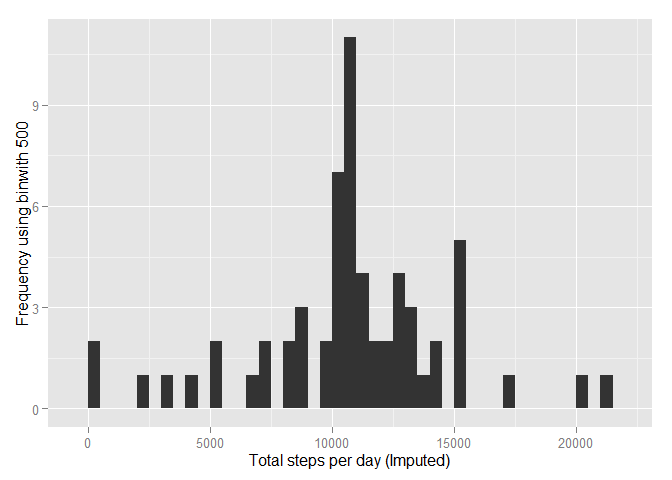

```r
qplot(ImputedStepsByDay,
      xlab='Total steps per day (Imputed)',
      ylab='Frequency using binwith 500',
      binwidth=500)
```

```r
ImputedStepsByDayMean <- mean(ImputedStepsByDay)
ImputedStepsByDayMedian <- median(ImputedStepsByDay)
```

## Are there differences in activity patterns between weekdays and weekends?

For this part the weekdays() function may be of some help here. Use the dataset with the filled-in missing values for this part.

#### 1.Create a new factor variable in the dataset with two levels - “weekday” and “weekend” indicating whether a given date is a weekday or weekend day.

```r
ImputedSet$dateType <-  ifelse(as.POSIXlt(ImputedSet$date)$wday %in% c(0,6), 'weekend', 'weekday')
```

#### 1.Make a panel plot containing a time series plot (i.e. type = “l”) of the 5-minute interval (x-axis) and the average number of steps taken, averaged across all weekday days or weekend days (y-axis). See the README file in the GitHub repository to see an example of what this plot should look like using simulated data.

- Panel using ggplot2

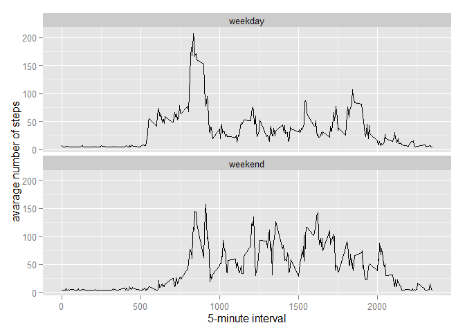

```r
ImputedSet <- aggregate(steps ~ interval + dateType, data=ImputedSet, mean)
ggplot(ImputedSet, aes(interval, steps)) +
    geom_line() +
    facet_grid( ~ dateType) +
    facet_wrap( ~ dateType, ncol=1) +
    xlab("5-minute interval") +
    ylab("avarage number of steps")
```

- Panel using lattice

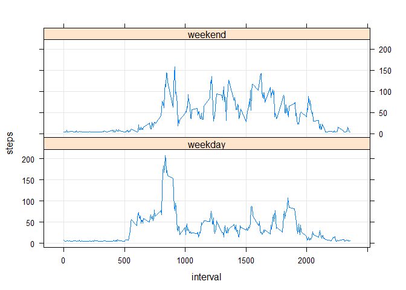

```r
xyplot(steps ~ interval | dateType,
       data = ImputedSet,
       type = c("l","g"),
       layout=c(1,2)
)
```